# Statistical Inference: Peer Assessment Part 1

## Part 1: Simulation excercise

### Overview

In this project the exponential distribution in R will be investigated and compared with the Central Limit Theorem. The exponential distribution can be simulated in R with rexp(n, lambda) where lambda is the rate parameter. The mean of exponential distribution is 1/lambda and the standard deviation is also 1/lambda. Set lambda = 0.2 for all of the simulations. The distribution of averages of 40 exponentials will be investigated. A thousand simulations will be done.

1. Show the sample mean and compare it to the theoretical mean of the distribution.
2. Show how variable the sample is (via variance) and compare it to the theoretical variance of the distribution.
3. Show that the distribution is approximately normal.

### Simulations

*load libraries*

```r
library(knitr)
library(ggplot2)
```

*set seed to create reproducability*

```r
set.seed(123)
```

*set the variables*

```r
n <- 40
lambda <- 0.2
num_sim <- 1000
```

*run the simulations*

Each element of c() is the mean of 40 randomly exponentials. There are 1000 simulation-runs, so c() consists of 1000 elements.

```r
means_row = NULL
for (i in 1 : 1000) means_row = c(means_row, mean(rexp(n,lambda)))
```

### Sample mean versus Theoretical mean

The sample mean is the mean over the 1000 row means.The theoretical mean is 1/lambda.

```r
mean_sample <- mean(means_row)
mean_theor <- 1/lambda
mean_sample
```

```
## [1] 5.011911
```

```r
mean_theor
```

```
## [1] 5
```

The sample mean (first value) is very close to the theoretical mean (second value). See also the plot in the paragraph “Distribution”.

### Sample variance versus Theoretical variance

The sample standard deviation is the standard deviation over the 1000 row means.The theoretical standard deviation is 1/lambda/sqrt(n). The variance is the squared standard deviation.

```r
sd_sample <- sd(means_row)
sd_theor <- 1/lambda/sqrt(n)
sd_sample
```

```
## [1] 0.7749147
```

```r
sd_theor
```

```
## [1] 0.7905694
```

The sample standard deviation (first value) is close to the theoretical standard deviation (second value).

The variance is the squared standard deviation.

```r
var_sample <- var(means_row)
var_theor <- sd_theor^2
var_sample
```

```
## [1] 0.6004928
```

```r
var_theor
```

```
## [1] 0.625
```

The sample variance (first value) is close to the theoretical variance (second value).

### Distribution

Via a graph will be shown that the distribution of averages of 40 exponentials is approximately normal. The graph is developed with ggplot() as shown in the code below:

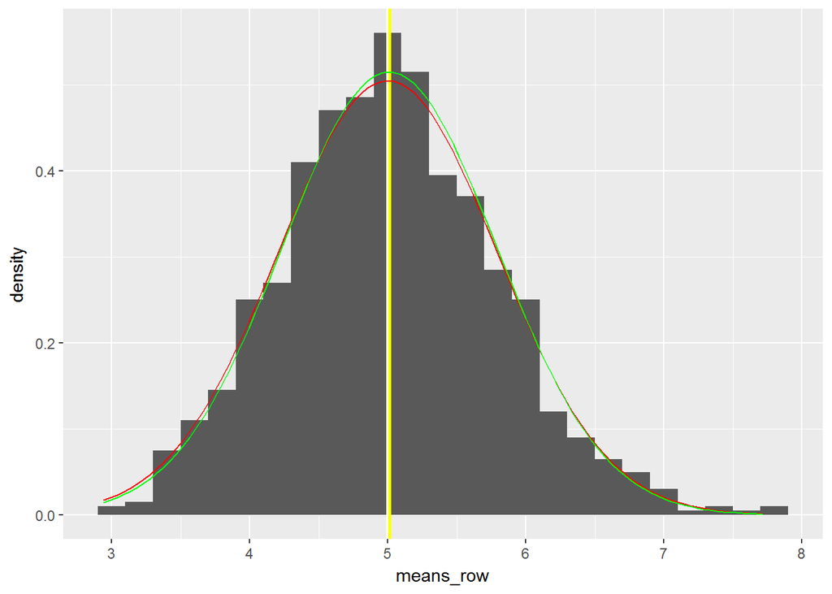

```r
graph_data <- data.frame(means_row)
distr_graph <- ggplot(graph_data, aes(x = means_row)) +
  geom_histogram(binwidth = lambda, aes(y = ..density..)) +
  geom_vline(xintercept = mean_theor, colour = "white", size = 1) +
  geom_vline(xintercept = mean_sample, colour = "yellow", size = 1) +
  stat_function(fun = dnorm, args = list(mean = mean_theor, sd = sd_theor), colour = "red") +
  stat_function(fun = dnorm, args = list(mean = mean_sample, sd = sd_sample), colour = "green")
  distr_graph
```